# Predicting Life Expectancy based on Socio-Economic and Health Factors

Sinja Sharma

# 1 Introduction

Life expectancy, the average number of years a person is expected to live based on current mortality rates, serves as a key indicator of population health and social development. Over the past century, improvements in medical technology, sanitation, nutrition, public health interventions have stabilized economic growth and stability which has a direct impact on global life expectancy. This stability has been lead to an increasing life expectancy globally. However, there are still existing disparities between regions and countries which are driven by social, economic, and health factors. Understanding how these drivers play a critical role in global health and public health efforts in reducing health and socioeconomic inequities.

# 2 Dataset and Feature Variables

This dataset contains 2,938 observations and 22 variables, covering life expectancy and related health and social indicators for multiple nations from 2000 to 2015. The dataset includes country-wide and other economic, social and health metrics. The dataset contains 193 total countries.

```r
life_ex <- read.csv("https://sin-ja.github.io/STA552/Project3/Life_Expectancy_Data.csv", stringsAsFactors = FALSE)
life_copy <- life_ex
names(life_ex)
```

```
 [1] "Country"                         "Year"
 [3] "Status"                          "Life.expectancy"
 [5] "Adult.Mortality"                 "infant.deaths"
 [7] "Alcohol"                         "percentage.expenditure"
 [9] "Hepatitis.B"                     "Measles"
[11] "BMI"                             "under.five.deaths"
[13] "Polio"                           "Total.expenditure"
[15] "Diphtheria"                      "HIV.AIDS"
[17] "GDP"                             "Population"
[19] "thinness..1.19.years"            "thinness.5.9.years"
[21] "Income.composition.of.resources" "Schooling"
```

```r
#str(life_ex)
#summary(life_ex)
#glimpse(life_ex)
```

Variable Description:

1. Country - Name of the country
2. Year - Data year from 2000 to 2015
3. Status - Economic Classification (Developing/ Developed)
4. Life Expectancy - Avergae lifespan in years
5. Adult Mortality - Probability of death between ages 15 - 60 per 1000 individuals
6. Infant Deaths - Number of infant deaths per 1000 live births
7. Alcohol - Per capita alcohol consumption
8. Percentage Expenditure - Government health expenditure as a percentage of GDP
9. Hepatitis B - Immunization coverage percentage
10. Measles - Number of reported measles cases
11. BMI - Average Body Mass Index
12. Under-Five Deaths - Mortality rate for children under five
13. Polio & Diphtheria - Immunization rates
14. HIV/AIDS - Deaths due to HIV/AIDS per 1000 individuals
15. GDP - Gross Domestic Product per capita
16. Population - Total population of the country
17. Thinness (1-19 years, 5-9 years) - Percentage of underweight children
18. Income Composition of Resources - Human development index proxy
19. Schooling - Average number of years of schooling

# 3 Handling Missing Values

Handling missing values is a critical step in data preprocessing and analysis. However, Classification and Regression Tree (CART) methods have a built-in mechanism to address missing data through surrogate splits, allowing observations with incomplete predictor values to still contribute to the model.

```r
# Total missing values per column
colSums(is.na(life_ex))
```

```
                        Country                            Year
                              0                               0
                         Status                 Life.expectancy
                              0                              10
                Adult.Mortality                   infant.deaths
                             10                               0
                        Alcohol          percentage.expenditure
                            194                               0
                    Hepatitis.B                         Measles
                            553                               0
                            BMI               under.five.deaths
                             34                               0
                          Polio               Total.expenditure
                             19                             226
                     Diphtheria                        HIV.AIDS
                             19                               0
                            GDP                      Population
                            448                             652
           thinness..1.19.years              thinness.5.9.years
                             34                              34
Income.composition.of.resources                       Schooling
                            167                             163
```

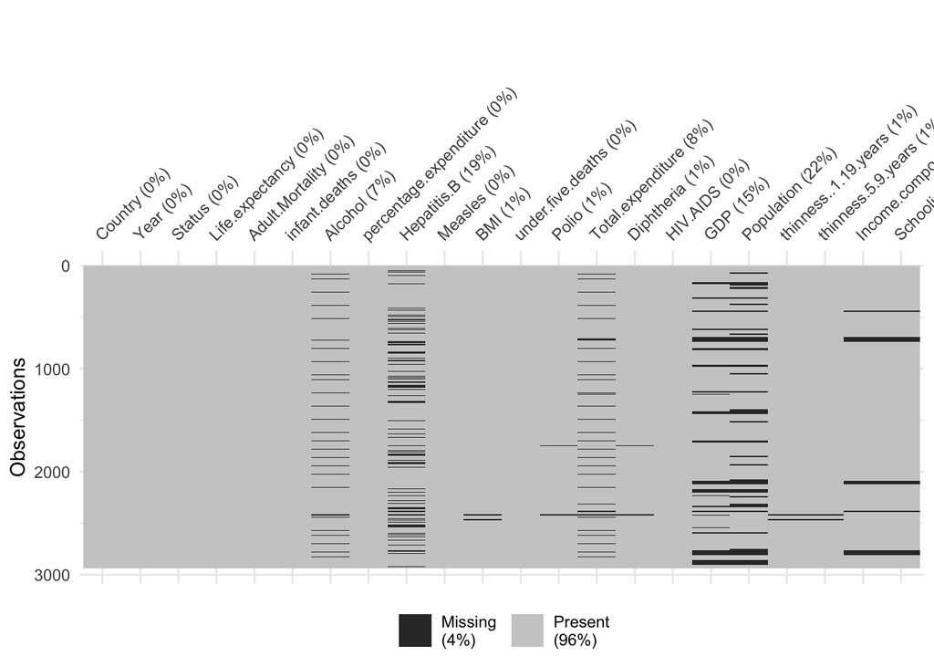

```r
#  Remove rows with missing Life.expectancy
miss_ex <- life_ex %>% filter(!is.na(Life.expectancy))

# Check for missing values in key predictors
#key_vars <- miss_ex %>% select(Life.expectancy, Adult.Mortality, BMI, GDP, Status, infant.deaths, Alcohol, percentage.expenditure, Hepatitis.B, Measles, under.five.deaths, Polio, Total.expenditure, Diphtheria, HIV.AIDS, Population, thinness..1.19.years, thinness.5.9.years, Income.composition.of.resources, Schooling)
#summary(key_vars)

# Visualize missing data
vis_miss(life_ex)
```

```r
# Further clean the dataset by removing rows with missing key predictors.
LE_clean <- miss_ex %>% drop_na(Adult.Mortality, BMI, GDP, Status, infant.deaths, Alcohol, percentage.expenditure, Hepatitis.B, Measles, under.five.deaths, Polio, Total.expenditure, Diphtheria, HIV.AIDS, Population, thinness..1.19.years, thinness.5.9.years, Income.composition.of.resources, Schooling)
```

Missing data overview: Some variables have missing values most notably:

Hepatitis B (553 missing) GDP (448 missing) Population (652 missing) Total expenditure (226 missing) Income Composition of Resources (167 missing) Schooling (163 missing)